# Model Deret Waktu: MA(2), AR(2), ARMA(2,2)

Fatima Azzahra - G1401231036

2025-09-21

# Proses MA(2)

## Pembangkitan Model

### Manual

**Pembangkitan White Noise** $(e_t)$

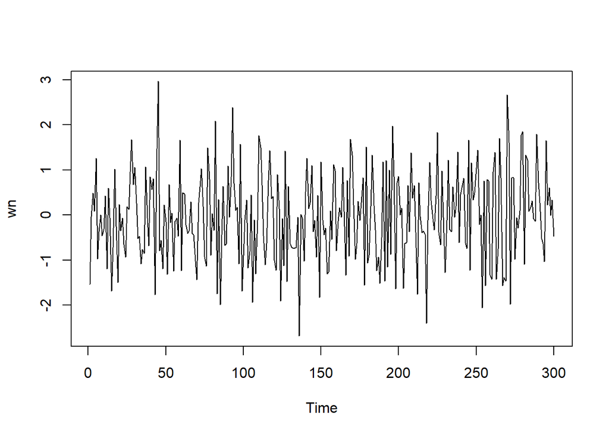

```r
set.seed(1036)
wn <- rnorm(300) #sebaran normal
ts.plot(wn)
```

**Pembangkitan Manual Model MA(2) dengan Proses Looping**

$$Y_t = e_t+0.4e_{t-1}+0.6e_{t-2}$$

```r
ma <- wn[c(1,2)] # nilai Yt untuk t=1,2 diisi dengan et untuk t=1,2
```

```r
# looping dari t=3 karena butuh 2 white noise sebelumnya yaaitu e_t-1 dan e_t-2
for(t in 3:300){
   ma[t] <- wn[t] + 0.4 * wn[t - 1] + 0.6 * wn[t - 2]
}
ma
```

```
##   [1] -1.535390477 -0.036309699 -0.451964906  0.260638912  1.584171049
##   [6] -0.412711092 -0.005001443 -0.731704195 -0.687450876 -0.498991034
##  [11]  0.018027175 -1.212541889  0.370783697 -0.534299700 -1.354534400
##  [16] -1.433369881 -0.285412241 -0.270358440 -0.981403436 -0.505074726
##  [21] -1.148582987 -0.066305236 -0.886031785 -1.235257532 -0.575121684
##  [26] -0.355861060  1.123565388  2.133465822  1.918134038  2.328932040
##  [31]  1.094653788  0.217427562 -0.518653605 -1.583972889 -1.477883788
##  [36] -1.805584045  0.269429157 -0.145744507 -0.068971649  0.540930384
##  [41]  0.496940023  1.548936609 -1.101684214  0.758467499  2.297293719
##  [46]  0.980481614  0.906648270 -1.889613206 -0.586239845 -0.770187313
##  [51] -1.239888472  0.063041921 -0.682979639  0.380484105 -1.323456915
##  [56] -0.610926792 -0.862903198 -0.581768061  1.436376836 -0.850622581
##  [61]  1.005715751 -0.069018509  0.269172324 -0.217147405 -0.644479130
##  [66] -0.095483452 -0.504699143 -0.430544586 -1.445710532 -2.105258343
##  [71] -0.908168918 -0.123271211  1.449569932  0.984677078 -0.219548943
```

[output cut: 45 more lines]

### Fungsi arima.sim

```r
set.seed(1036)
ma_arima <- arima.sim(model = list(order = c(0,0,2), ma = c(0.4,0.6)), n = 300)
ma_arima
```

```
## Time Series:
## Start = 1
## End = 300
## Frequency = 1
##   [1] -0.451964906  0.260638912  1.584171049 -0.412711092 -0.005001443
##   [6] -0.731704195 -0.687450876 -0.498991034  0.018027175 -1.212541889
##  [11]  0.370783697 -0.534299700 -1.354534400 -1.433369881 -0.285412241
##  [16] -0.270358440 -0.981403436 -0.505074726 -1.148582987 -0.066305236
##  [21] -0.886031785 -1.235257532 -0.575121684 -0.355861060  1.123565388
##  [26]  2.133465822  1.918134038  2.328932040  1.094653788  0.217427562
##  [31] -0.518653605 -1.583972889 -1.477883788 -1.805584045  0.269429157
##  [36] -0.145744507 -0.068971649  0.540930384  0.496940023  1.548936609
##  [41] -1.101684214  0.758467499  2.297293719  0.980481614  0.906648270
##  [46] -1.889613206 -0.586239845 -0.770187313 -1.239888472  0.063041921
##  [51] -0.682979639  0.380484105 -1.323456915 -0.610926792 -0.862903198
```

[output cut: 49 more lines]

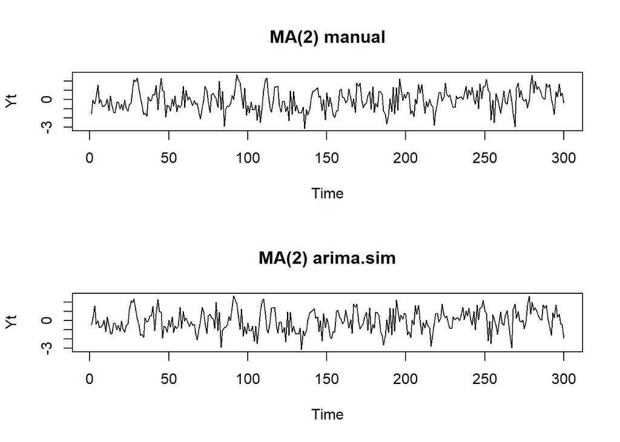

```r
par(mfrow=c(2,1))
ts.plot(ma, main="MA(2) manual", ylab="Yt")
ts.plot(ma_arima, main="MA(2) arima.sim", ylab="Yt")
```

## Karakteristik MA(2)

### Plot Time Series

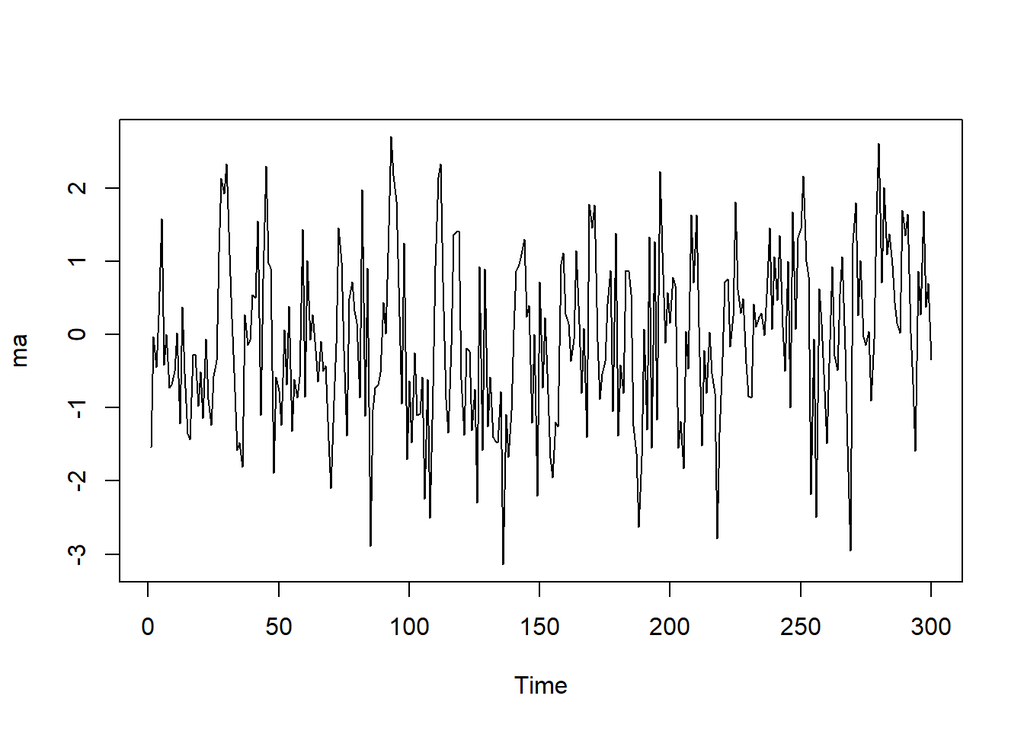

```r
ts.plot(ma)
```

Berdasarkan plot time series, terlihat bahwa data MA(2) yang dibangkitkan stasioner dalam rataan.

### Plot ACF (Cut off di lag berapa)

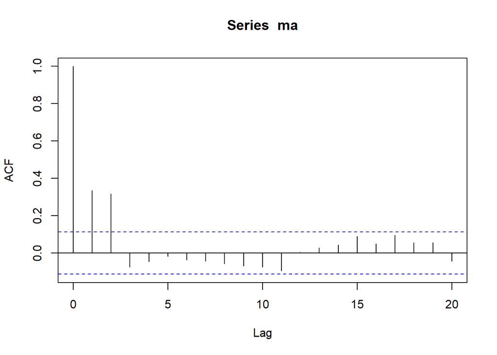

```r
acf(ma,lag.max = 20)
```

Berdasarkan plot AFC tersebut, terlihat bahwa plot ACF *cuts off* di lag pertama dan kedua.

### Plot PACF (Tails off di lag berapa)

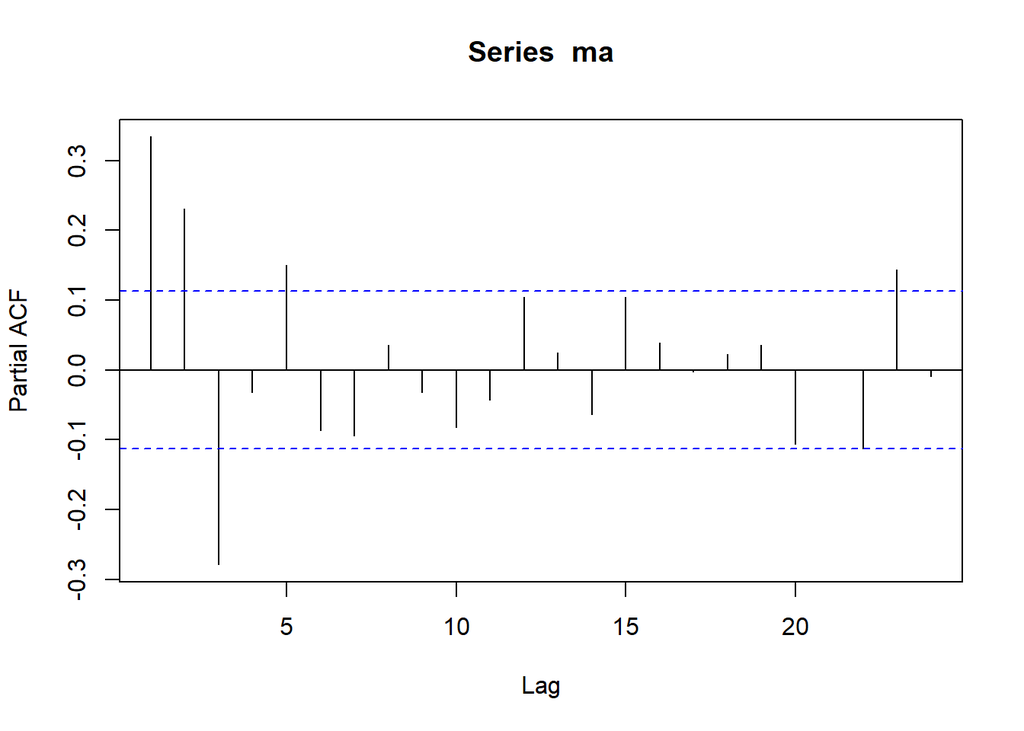

```r
pacf(ma)
```

Berdasarkan plot PACF tersebut, terlihat bahwa plot PACF cenderung *tails off* dan membentuk gelombang sinus.

### Plot EACF (Kalo di ACF PACF Cut off dan Tails off sama, pastikan dengan EACF)

```r
TSA::eacf(ma)
```

```
## AR/MA
##   0 1 2 3 4 5 6 7 8 9 10 11 12 13
## 0 x x o o o o o o o o o  o  o  o
## 1 x x x o o o o o o o o  o  o  o
## 2 x x x o o o o o o o o  o  o  o
## 3 o x x o o o o o o o o  o  o  o
## 4 x x x x o o o o o o o  o  o  o
## 5 x x x x o o o o o o o  o  o  o
## 6 x x x o o o o o o o o  o  o  o
## 7 x x x x o o o o o o o  o  o  o
```

Berdasarkan pola segitiga nol pada plot EACF, terlihat bahwa segitiga nol berada pada ordo AR(0) dan ordo MA(2).

### Scatterplot Antar Lag

**Korelasi antara Y_t dengan Y_{t-1}**

```r
#Yt
yt_ma <- ma[-1]
#Yt-1
yt_1_ma <- ma[-300]
```

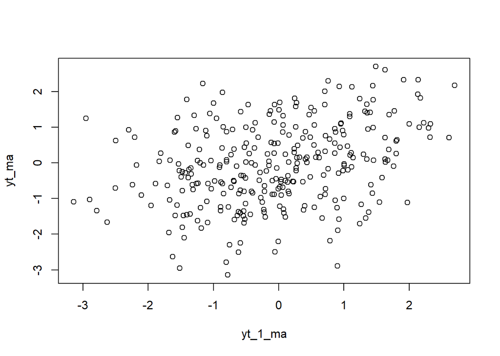

```r
plot(y=yt_ma,x=yt_1_ma)
```

Berdasarkan scatterplot tersebut, terlihat bahwa terdapat hubungan positif antara $Y_t$ dengan $Y_{t-1}$. Hal ini sesuai dengan teori yang ada.

```r
cor(yt_ma,yt_1_ma)
```

```
## [1] 0.3350171
```

Korelasi antara $Y_t$ dengan $Y_{t-1}$ dari hasil simulasi mendekati perhitungan teoritis yaitu

$$\rho_1=\frac{\theta_1 + \theta_1
\theta_2}{1+\theta_1^2+\theta_2^2}=\frac{(0.4)+(0.24)}{1+(0.4)^2+(0.6)^2}=0.42$$

**Korelasi antara Y_t dengan Y_{t-2}**

```r
#YT
yt_ma   <- ma[-c(1,2)]
#Yt-2
yt_2_ma  <- ma[-c(299,300)]
```

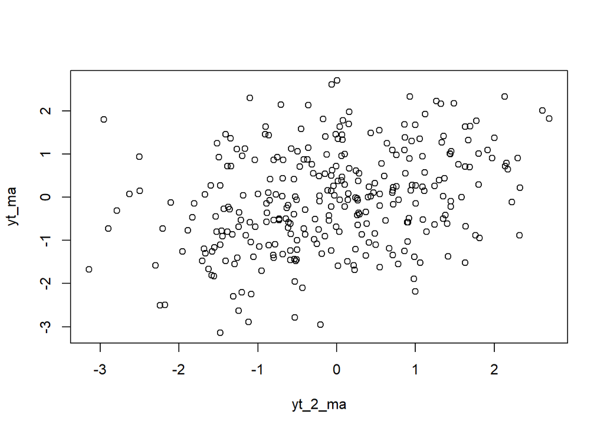

```r
plot(y=yt_ma,x=yt_2_ma)
```

Berdasarkan scatterplot tersebut, terlihat bahwa terdapat hubungan positif antara $Y_t$ dengan $Y_{t-2}$. Hal ini sesuai dengan teori yang ada.

```r
cor(yt_ma,yt_2_ma)
```

```
## [1] 0.3175869
```

Korelasi antara $Y_t$ dengan $Y_{t-2}$ dari hasil simulasi mendekati perhitungan teoritis yaitu

$$\rho_1=\frac{\theta_2}{1+\theta_1^2+\theta_2^2}=\frac{(0.6)}{1+(0.4)^2+(0.6)^2}=0.39$$

**Korelasi antara Y_t dengan Y_{t-3}**

```r
#YT
yt_ma   <- ma[-c(1,2,3)]
#Yt-2
yt_3_ma  <- ma[-c(298,299,300)]
```

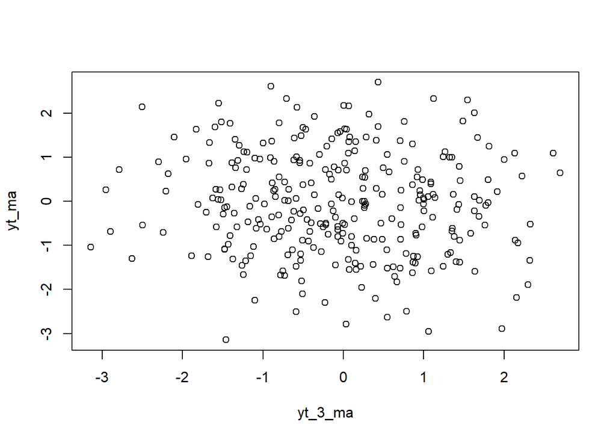

```r
plot(y=yt_ma,x=yt_3_ma)
```

Berdasarkan scatterplot tersebut, terlihat bahwa cenderung tidak terdapat hubungan antara $Y_t$ dengan $Y_{t-3}$.

```r
cor(yt_ma,yt_3_ma)
```

```
## [1] -0.07626661
```

Korelasi antara $Y_t$ dengan $Y_{t-2}$ hasil simulasi mendekati teori yang ada yaitu 0.

# Proses AR(2)

## Pembangkitan Model

### Manual

$$Y_t = e_t+0.5Y_{t-1}+0.2Y_{t-2}$$

```r
set.seed(1036)
wn <- rnorm(300)
n<-length(wn)
n
```

```
## [1] 300
```

```r
# Nilai Yt untuk t=1,2 di set 1 dan 2
ar <- c(1:n)
```

```r
for (t in 3:300){
  ar[t] <- wn[t] + 0.5 * ar[t-1] + 0.2 * ar[t-2]
  }
ar
```

```
##   [1]  1.000000000  2.000000000  1.683793260  1.330804057  2.260492802
##   [6]  0.427018815  0.293362611  0.230912055 -0.289505907 -0.411403985
##  [11]  0.157738052 -1.196790084  0.028482855 -0.281521416 -1.824234778
##  [16] -1.692280400 -0.193353520 -0.678229497 -1.872530407 -0.833229853
##  [21] -1.138329522 -0.806441312 -1.280341005 -1.734556171 -0.935556341
##  [26] -0.685807999  0.429323590  1.749901631  1.634385683  2.223236286
##  [31]  1.706581731  0.774493233  0.258435443 -0.797738579 -1.110247498
##  [36] -1.565916423  0.062758608 -0.343908040 -0.844192115  0.361231080
##  [41]  0.578747532  1.172503178 -1.064218646  0.680816790  3.093220039
##  [46]  0.889937556  0.508002161 -0.759678871 -0.054445488 -0.323862760
##  [51] -1.489103362 -0.132946613 -0.528054935 -0.250454874 -1.472103532
##  [56] -0.924660640 -0.819488000 -1.068238660  0.965427104 -0.962796855
##  [61]  0.212081394  0.383422661  0.015086759 -0.327267954 -0.509072898
##  [66] -0.029193463 -0.528355321 -0.710261282 -1.483247860 -2.315809110
##  [71] -1.176402182 -0.426615147  0.584191648  0.403489350 -0.599320356
```

[output cut: 45 more lines]

### Fungsi arima.sim

```r
ar_arima <- arima.sim(model = list(order = c(2,0,0), ar = c(0.5,0.2)), n = n)
ar_arima
```

```
## Time Series:
## Start = 1
## End = 300
## Frequency = 1
##   [1]  0.990244901  1.028021189  0.878563259  1.052627082  1.104807357
##   [6]  1.359971606  0.934142436  0.002196843  0.049364376  0.419972837
##  [11] -1.603192999 -1.159524647 -2.060010647 -2.617644586 -1.352782779
##  [16]  0.288255486 -1.200872495 -2.830369161 -1.747670536 -1.251069780
##  [21]  0.167221156 -0.022530866 -0.014335631 -0.814472816 -0.706134136
##  [26] -0.128921456  0.614769439  0.199737500 -0.169929258 -2.281733125
##  [31] -0.242302783  1.478048365  2.195597888  0.684065946  0.136250778
##  [36] -1.414241700 -3.017726329 -2.519682218 -1.761368494 -2.142624554
##  [41]  0.300898112 -1.452255767  0.509081400  1.806803369 -0.351966364
##  [46]  0.601879780 -0.037079570 -2.574028125 -0.173684505 -0.517192986
##  [51] -0.182326345  1.667250704  1.362198743  1.471305790  0.171445289
```

[output cut: 49 more lines]

## Karakteristik AR(2)

### Plot Time Series

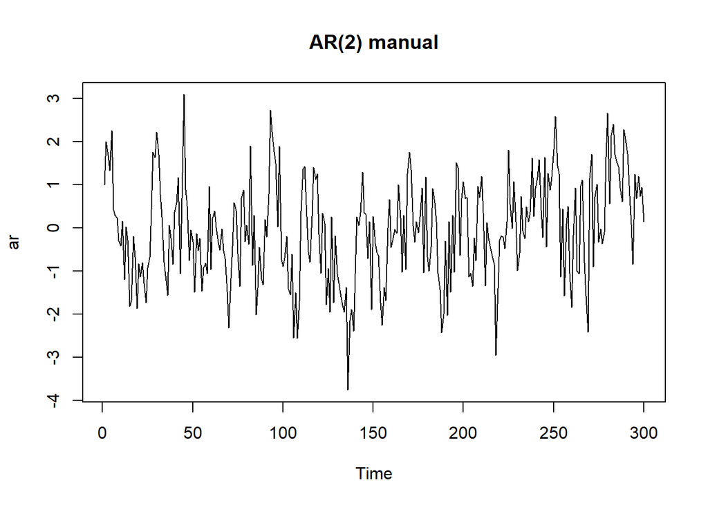

```r
ts.plot(ar,  main = "AR(2) manual")
```

Berdasarkan plot time series tersebut terlihat bahwa data cenderung stasioner pada rataan.

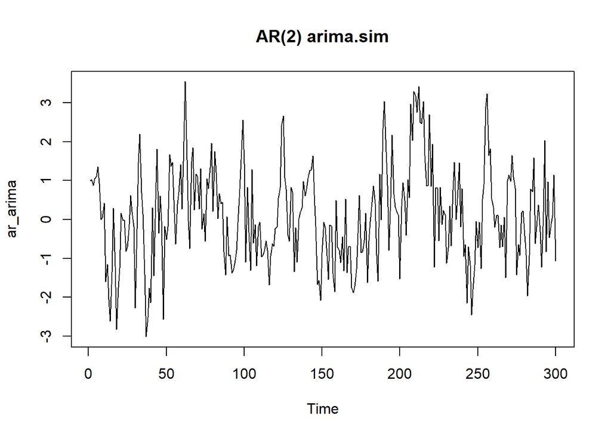

```r
ts.plot(ar_arima,  main = "AR(2) arima.sim")
```

### Plot ACF (di AR Tails off)

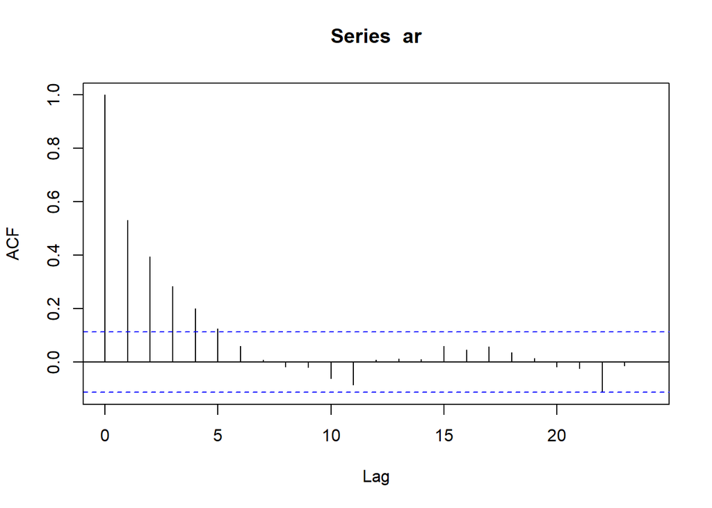

```r
acf(ar)
```

Berdasarkan plot ACF tersebut terlihat bahwa plot ACF cenderung *tails off* dan cenderung membentuk pola grafik sinus.

### Plot PACF (di AR Cut off)

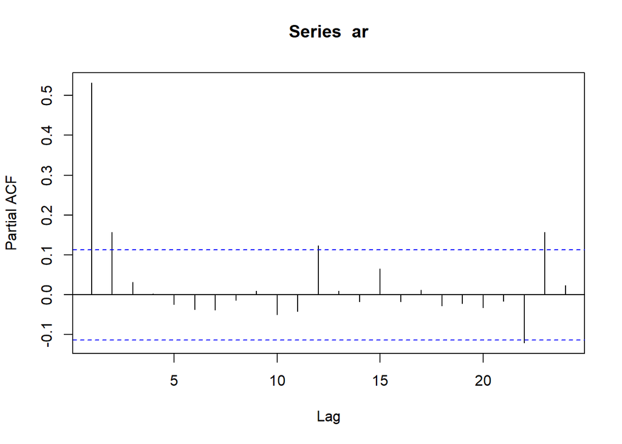

```r
pacf(ar)
```

Berdasarkan plot PACF tersebut, terlihat bahwa plot PACF *cuts off* di lag-1 dan lag-2. Hal ini sesuai dengan teori.

### Plot EACF

```r
TSA::eacf(ar)
```

```
## AR/MA
##   0 1 2 3 4 5 6 7 8 9 10 11 12 13
## 0 x x x x x o o o o o o  o  o  o
## 1 x o o o o o o o o o o  o  o  o
## 2 x o o o o o o o o o o  o  o  o
## 3 x o o o o o o o o o o  o  o  o
## 4 x x o o o o o o o o o  o  o  o
## 5 x x o o o o o o o o o  o  o  o
## 6 x x x o o o o o o o o  o  o  o
## 7 x x o o o o o o o o o  o  o  o
```

### Scatterplot Antar Lag

**Korelasi antara Y_t dengan Y_{t-1}**

```r
#Yt
yt_ar <- ar[-1]
#Yt-1
yt_1_ar <- ar[-300]
```

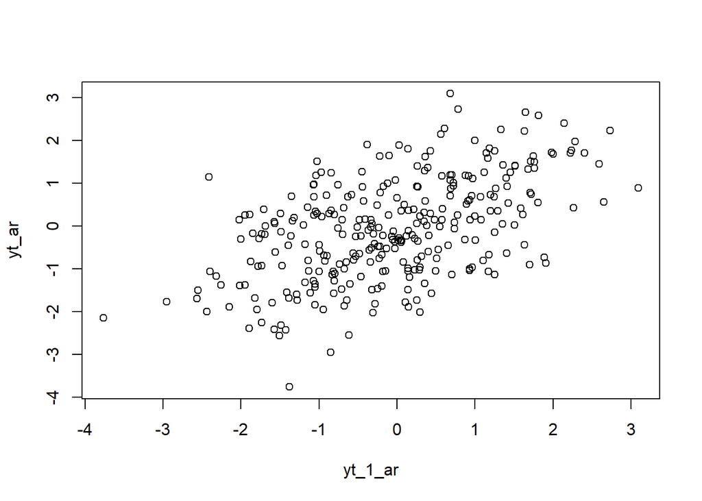

```r
plot(y=yt_ar,x=yt_1_ar)
```

Berdasarkan scatterplot tersebut, terlihat bahwa terdapat hubungan positif antara $Y_t$ dengan $Y_{t-1}$. Hal ini sesuai dengan teori yang ada.

```r
cor(yt_ar,yt_1_ar)
```

```
## [1] 0.5318965
```

Korelasi antara $Y_t$ dengan $Y_{t-1}$ dari hasil simulasi mendekati perhitungan teoritis yaitu

$$\rho_1=
\frac{\phi_1}{1-\phi_2}=\frac{0.5}{1-0.2}=0.6$$

**Korelasi antara Y_t dengan Y_{t-2}**

```r
#Yt
yt_ar <- ar[-c(1,2)]
#Yt-2
yt_2_ar <- ar[-c(299,300)]
```

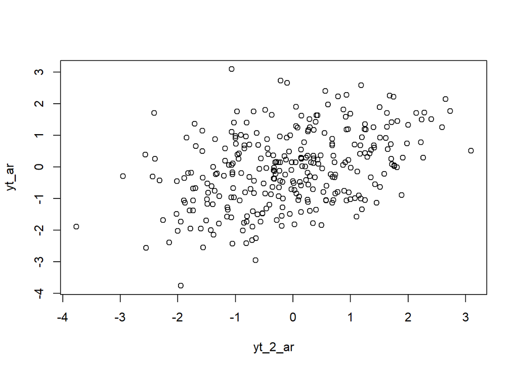

```r
plot(y=yt_ar,x=yt_2_ar)
```

Berdasarkan scatterplot tersebut, terlihat bahwa terdapat hubungan positif antara $Y_t$ dengan $Y_{t-2}$. Hal ini sesuai dengan teori yang ada.

```r
cor(yt_ar,yt_2_ar)
```

```
## [1] 0.3977712
```

Korelasi antara $Y_t$ dengan $Y_{t-2}$ dari hasil simulasi mendekati perhitungan teoritis yaitu

$$\rho_1= \phi_1\rho_1+ \phi_2
\rho_0=(0.5)(0.6)+(0.2)=0.5$$

**Korelasi antara Y_t dengan Y_{t-3}**

```r
#Yt
yt_ar <- ar[-c(1,2,3)]
#Yt-2
yt_3_ar <- ar[-c(298,299,300)]
```

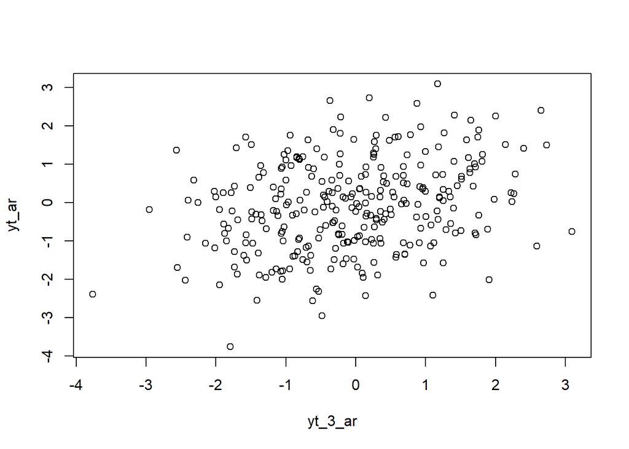

```r
plot(y=yt_ar,x=yt_3_ar)
```

Berdasarkan scatterplot tersebut, terlihat bahwa terdapat hubungan positif antara $Y_t$ dengan $Y_{t-3}$. Hal ini sesuai dengan teori yang ada.

```r
cor(yt_ar,yt_3_ar)
```

```
## [1] 0.2857469
```

# Proses ARMA(2,2)

## Pembangkita Model

### Manual

$$Y_{t} = 0.5Y_{t-1} + 0.2Y_{t-2} + 0.4e_{t-1}+0.6e_{t-2}+ e_{t}$$

```r
set.seed(1036)
wn <- rnorm(300)

phi1 <- 0.5
phi2 <- 0.2
theta1 <- 0.4
theta2 <- 0.6

y.arma <- numeric(300)
# inisialisasi nilai awal
y.arma[1:2] <- 0

for (i in 3:300) {
  y.arma[i] <- phi1*y.arma[i-1] + phi2*y.arma[i-2] +
               wn[i] + theta1*wn[i-1] + theta2*wn[i-2]
}

y.arma
```

```
##   [1]  0.00000000  0.00000000 -0.45196491  0.03465646  1.51110630  0.34977335
##   [7]  0.47210649 -0.42569628 -0.80587772 -0.98706915 -0.63668294 -1.72829719
##  [13] -0.62070149 -1.19030988 -2.07382964 -2.70834668 -2.05435151 -1.83920353
##  [19] -2.31187550 -2.02885318 -2.62538468 -1.78476821 -2.30349283 -2.74395759
##  [25] -2.40779904 -2.10855210 -0.41227047  1.50562017  2.58849003  3.92430109
##  [31]  3.57450234  2.78953895  1.59101634 -0.23055693 -1.27495899 -2.48917492
##  [37] -1.23015010 -1.25865454 -0.94432894 -0.18296499  0.21659174  1.62063948
##  [43] -0.24804613  0.95857233  2.72697066  2.53568141  2.71988311 -0.02253537
##  [49] -0.05353091 -0.80145984 -1.65132457 -0.92291233 -1.47470072 -0.54144872
##  [55] -1.88912142 -1.66377725 -2.07261611 -1.95083156  0.04643783 -1.21756998
##  [61]  0.40621833 -0.10942334  0.29570432 -0.09117991 -0.63092822 -0.42918355
##  [67] -0.84547656 -0.93911958 -2.08436563 -3.33526507 -2.99267458 -2.28666152
##  [73] -0.29229574  0.38119690 -0.08740964 -1.35145157 -0.20858405  0.33763889
##  [79]  0.44660917  0.45013929 -0.54827908  1.78723054 -0.33371967  1.09054215
##  [85] -2.41625187 -2.01871205 -2.22253522 -2.19803427 -2.06743057 -1.03944189
```

[output cut: 35 more lines]

### Fungsi arima.sim

```r
arma_arima <- arima.sim(model = list(order = c(2,0,2), ar = c(0.5, 0.2), ma = c(0.4, 0.6)), n = 300)
arma_arima
```

```
## Time Series:
## Start = 1
## End = 300
## Frequency = 1
##   [1]  1.885155472  2.021807968  2.053714939  2.434018769  2.141433237
##   [6]  1.192155248  0.610971357  0.441221777 -1.405444141 -1.548710578
##  [11] -3.485654302 -4.137301118 -3.635799343 -1.823408046 -1.897212270
##  [16] -3.137743753 -3.600325600 -3.648347219 -1.381799722 -0.706277139
##  [21]  0.076990154 -0.833721443 -1.040521481 -0.900056392  0.139522211
##  [26]  0.368293802  0.278828473 -2.229861514 -1.256952967  0.012087850
##  [31]  2.641435925  2.449134395  1.727236099 -0.949301662 -3.501672420
##  [36] -4.575317677 -4.579877108 -4.358981229 -1.612972765 -2.617471223
##  [41]  0.108717985  1.139082487  0.676203838  1.545175266 -0.007507468
##  [46] -2.227732080 -1.225543492 -2.131083659 -0.493414239  1.284004377
##  [51]  1.919703219  3.016535710  1.577286852  0.325426701  0.244210877
```

[output cut: 49 more lines]

## Karakteristik ARMA(2,2)

### Plot Time Series

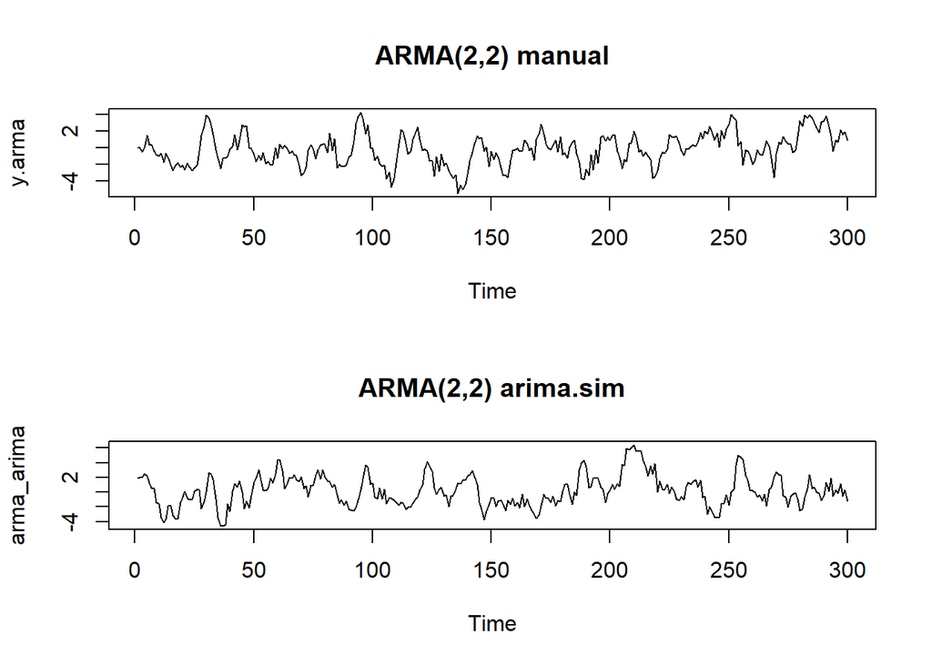

```r
par(mfrow = c(2, 1))
ts.plot(y.arma, main = "ARMA(2,2) manual")
ts.plot(arma_arima,  main = "ARMA(2,2) arima.sim")
```

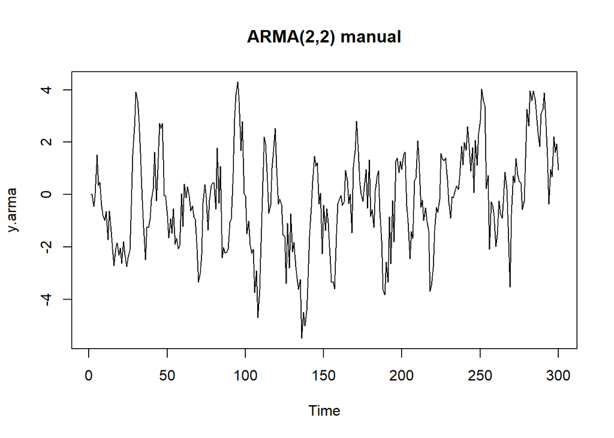

```r
ts.plot(y.arma,  main = "ARMA(2,2) manual")
```

Berdasarkan plot time series tersebut, terlihat bahwa model ARMA(2,2) cenderung stasioner dalam rataan.

### Plot ACF

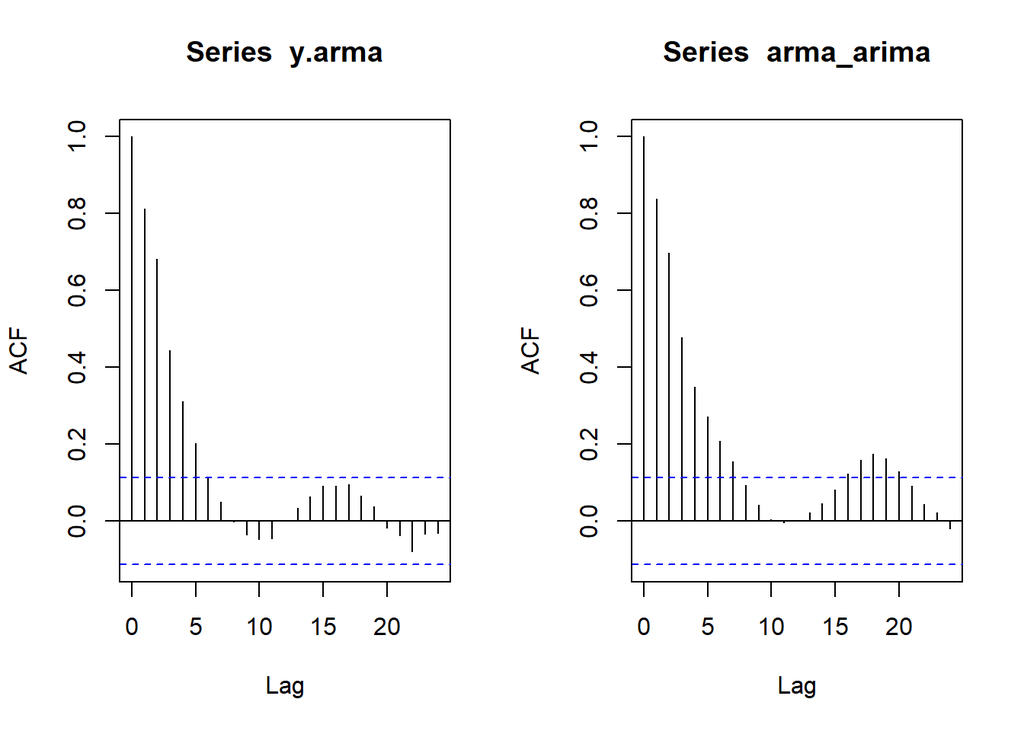

```r
par(mfrow = c(1, 2))
acf(y.arma)
acf(arma_arima)
```

Berdasarkan plot ACF tersebut, terlihat bahwa model ARMA(2,2) hasil simulasi memiliki plot ACF yang *tails off*, sesuai dengan teori yang ada

### Plot PACF

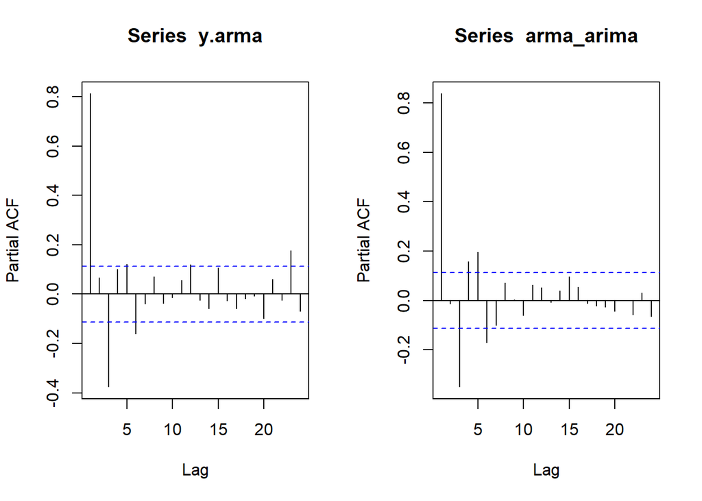

```r
par(mfrow = c(1, 2))
pacf(y.arma)
pacf(arma_arima)
```

Berdasarkan plot PACF tersebut, terlihat bahwa model ARMA(2,2) hasil simulasi memiliki plot PACF yang *tails off*, sesuai dengan teori.

### Plot EACF

```r
TSA::eacf(y.arma)
```

```
## AR/MA
##   0 1 2 3 4 5 6 7 8 9 10 11 12 13
## 0 x x x x x o o o o o o  o  o  o
## 1 o x o o o o o o o o o  o  o  o
## 2 x x x o o o o o o o o  o  o  o
## 3 x x x o x o o o o o o  o  o  o
## 4 x x x o x o o o o o o  o  o  o
## 5 x x x x o o o o o o o  o  o  o
## 6 x x x o o o o o o o o  o  o  o
## 7 x x o x o o o o o o o  o  o  o
```

```r
TSA::eacf(arma_arima)
```

```
## AR/MA
##   0 1 2 3 4 5 6 7 8 9 10 11 12 13
## 0 x x x x x x x o o o o  o  o  o
## 1 o x o o o o o o o o o  o  o  o
## 2 o x x o o o o o o o o  o  o  o
## 3 x x x o o o o o o o o  o  o  o
## 4 x x o o x o o o o o o  o  o  o
## 5 x x o x x o o o o o o  o  o  o
## 6 x x x o x o x o o o o  o  o  o
## 7 x x x o x o o o o o o  o  o  o
```

### Scatterplot Antar Lag

**Korelasi antara Y_t dengan Y_{t-1}**

```r
#Yt
yt_arma <- arma_arima[-1]
#Yt-1
yt_1_arma <- arma_arima[-300]
```

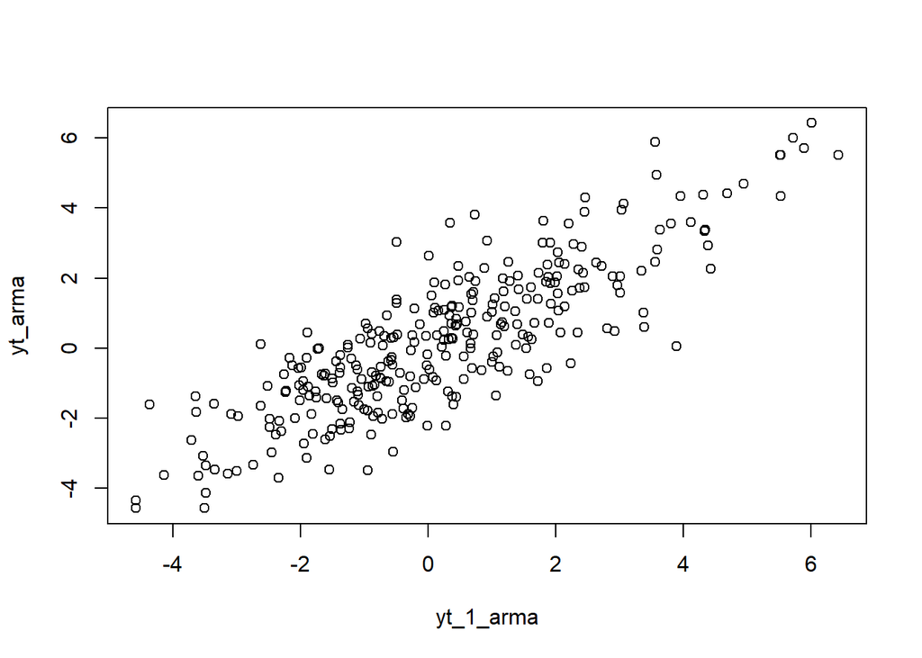

```r
plot(y=yt_arma,x=yt_1_arma)
```

Berdasarkan scatterplot tersebut, terlihat bahwa terdapat hubungan positif antara $Y_t$ dengan $Y_{t-1}$. Hal ini sesuai dengan teori yang ada

```r
cor(yt_arma,yt_1_arma)
```

```
## [1] 0.8392749
```

Korelasi antara $Y_t$ dengan $Y_{t-1}$ dari hasil simulasi mendekati perhitungan teoritis.

$$\rho_1 =
\frac{
\phi_1\phi_2\theta_2+\phi_1\theta_1^{2}+\phi_1\theta_2^{2}+\phi_1-\phi_2\theta_1^{2}-\phi_2\theta_2^{2}-\phi_2-\theta_1-\theta_1\theta_2
}{
\phi_{1}^{2}\theta_{1}^{2}+\phi_{1}^{2}\theta_{2}^{2}-\phi_{1}^{2}\theta_{2}-\phi_{1}\phi_{2}\theta_{1}^{2}-\phi_{1}\phi_{2}\theta_{2}^{2}+\phi_{1}\phi_{2}\theta_{2}+\phi_{1}\phi_{2}-\phi_{1}\theta_{1}^{2}-\phi_{1}\theta_{2}^{2}+\phi_{1}+\phi_{2}\theta_{1}^{2}+\phi_{2}\theta_{2}^{2}+\phi_{2}\theta_{2}-\phi_{2}+\theta_{1}^{2}+\theta_{2}^{2}+1
}$$

Jika disubtitusi dengan $\phi_1=0.5$, $\phi_2=0.2$, $\theta_1=0.4$ dan $\theta_1=0.6$, nilai $\rho_1=0.8$

**Korelasi antara Y_t dengan Y_{t-2}**

```r
#Yt
yt_arma <- arma_arima[-c(1,2)]
#Yt-1
yt_2_arma <- arma_arima[-c(299,300)]
```

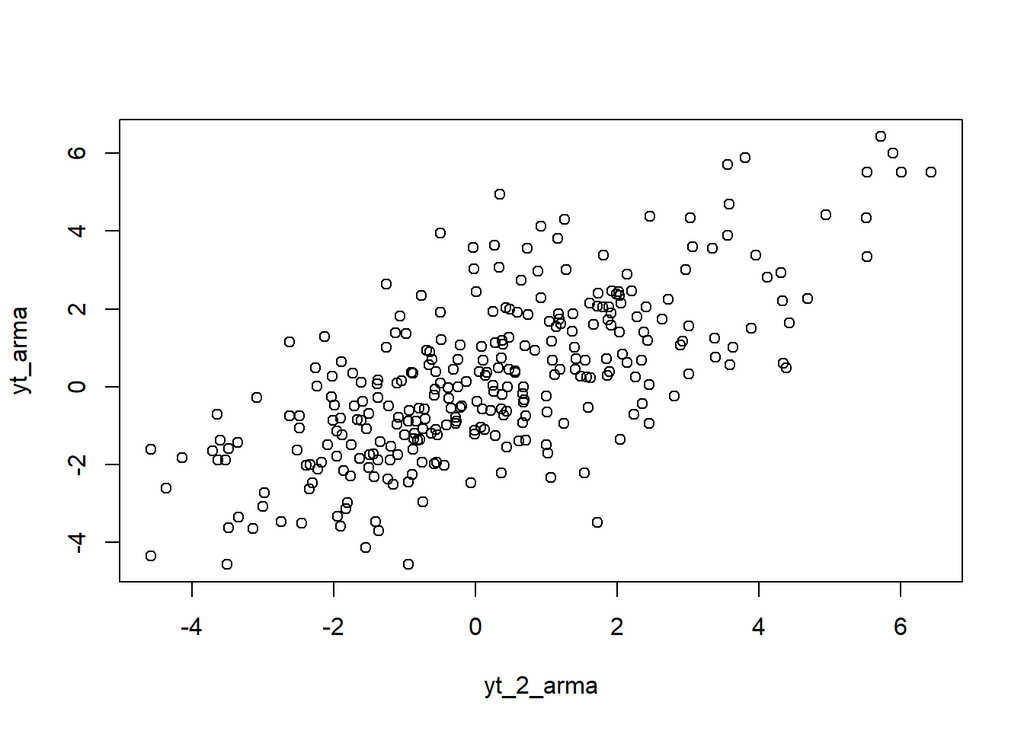

```r
plot(y=yt_arma,x=yt_2_arma)
```

Berdasarkan scatterplot tersebut, terlihat bahwa terdapat hubungan positif antara $Y_t$ dengan $Y_{t-1}$. Hal ini sesuai dengan teori yang ada

```r
cor(yt_arma,yt_2_arma)
```

```
## [1] 0.7000408
```

Korelasi antara $Y_t$ dengan $Y_{t-2}$ dari hasil simulasi mendekati perhitungan teoritis.

$$\rho_2 =
\frac{
\phi_{1}^{2}\theta_{1}^{2}+\phi_{1}^{2}\theta_{2}^{2}-\phi_{1}^{2}\theta_{2}+\phi_{1}\phi_{2}\theta_{1}^{2}+\phi_{1}\phi_{2}\theta_{2}^{2}-\phi_{1}\phi_{2}\theta_{2}+\phi_{2}\theta_{1}^{2}+\phi_{2}\theta_{2}^{2}+\phi_{2}\theta_{2}-\phi_{2}+\theta_{1}^{2}+\theta_{2}^{2}+1
}{
\phi_{1}^{2}\theta_{1}^{2}+\phi_{1}^{2}\theta_{2}^{2}-\phi_{1}^{2}\theta_{2}-\phi_{1}\phi_{2}\theta_{1}^{2}-\phi_{1}\phi_{2}\theta_{2}^{2}+\phi_{1}\phi_{2}\theta_{2}+\phi_{1}\phi_{2}-\phi_{1}\theta_{1}^{2}-\phi_{1}\theta_{2}^{2}+\phi_{1}+\phi_{2}\theta_{1}^{2}+\phi_{2}\theta_{2}^{2}+\phi_{2}\theta_{2}-\phi_{2}+\theta_{1}^{2}+\theta_{2}^{2}+1
}$$

Jika disubtitusi dengan $\phi_1=0.5$, $\phi_2=0.2$, $\theta_1=0.4$ dan $\theta_1=0.6$, nilai $\rho_2=0.7$

**Korelasi antara Y_t dengan Y_{t-3}**

```r
#Yt
yt_arma <- arma_arima[-c(1,2,3)]
#Yt-1
yt_3_arma <- arma_arima[-c(298,299,300)]
```

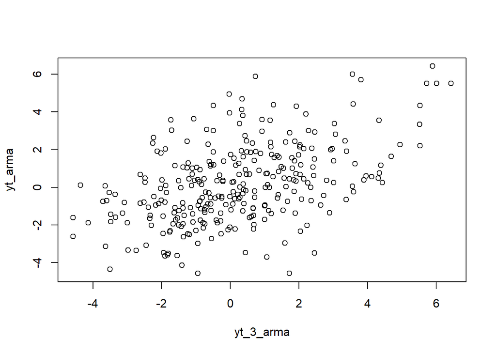

```r
plot(y=yt_arma,x=yt_3_arma)
```

Berdasarkan scatterplot tersebut, terlihat bahwa terdapat hubungan positif antara $Y_t$ dengan $Y_{t-1}$. Hal ini sesuai dengan teori yang ada

```r
cor(yt_arma,yt_3_arma)
```

```
## [1] 0.4790755
```

Korelasi antara $Y_t$ dengan $Y_{t-1}$ dari hasil simulasi mendekati perhitungan teoritis.

$$\rho_3 =
\frac{
\phi_{1}\big(\phi_{1}^{2}\theta_{1}^{2}+\phi_{1}^{2}\theta_{2}^{2}-\phi_{1}^{2}\theta_{2}+\phi_{1}\phi_{2}\theta_{1}^{2}+\phi_{1}\phi_{2}\theta_{2}^{2}-\phi_{1}\phi_{2}\theta_{2}+\phi_{2}\theta_{1}^{2}+\phi_{2}\theta_{2}^{2}+\phi_{2}\theta_{2}-\phi_{2}+\theta_{1}^{2}+\theta_{2}^{2}+1\big)
}{
\phi_{1}^{2}\theta_{1}^{2}+\phi_{1}^{2}\theta_{2}^{2}-\phi_{1}^{2}\theta_{2}-\phi_{1}\phi_{2}\theta_{1}^{2}-\phi_{1}\phi_{2}\theta_{2}^{2}+\phi_{1}\phi_{2}\theta_{2}+\phi_{1}\phi_{2}-\phi_{1}\theta_{1}^{2}-\phi_{1}\theta_{2}^{2}+\phi_{1}+\phi_{2}\theta_{1}^{2}+\phi_{2}\theta_{2}^{2}+\phi_{2}\theta_{2}-\phi_{2}+\theta_{1}^{2}+\theta_{2}^{2}+1
}$$

Jika disubtitusi dengan $\phi_1=0.5$, $\phi_2=0.2$, $\theta_1=0.4$ dan $\theta_1=0.6$, nilai $\rho_2=0.5$